# Introduction to data visualization, web scraping, and text analysis in R: Session 2

In-class Work

J.M.T. Roos

Last updated: 2019-06-26 14:55:28

# Excercise set 1

For Tasks 1–4 use the following data

```r
library(tidyverse)
mpg %>% tbl_df
```

```
## # A tibble: 234 x 11
##    manufacturer model displ  year   cyl trans drv     cty   hwy fl    class
##    <chr>        <chr> <dbl> <int> <int> <chr> <chr> <int> <int> <chr> <chr>
##  1 audi         a4      1.8  1999     4 auto… f        18    29 p     comp…
##  2 audi         a4      1.8  1999     4 manu… f        21    29 p     comp…
##  3 audi         a4      2    2008     4 manu… f        20    31 p     comp…
##  4 audi         a4      2    2008     4 auto… f        21    30 p     comp…
##  5 audi         a4      2.8  1999     6 auto… f        16    26 p     comp…
##  6 audi         a4      2.8  1999     6 manu… f        18    26 p     comp…
##  7 audi         a4      3.1  2008     6 auto… f        18    27 p     comp…
##  8 audi         a4 q…   1.8  1999     4 manu… 4        18    26 p     comp…
##  9 audi         a4 q…   1.8  1999     4 auto… 4        16    25 p     comp…
## 10 audi         a4 q…   2    2008     4 manu… 4        20    28 p     comp…
## # … with 224 more rows
```

## Task 1

- Create a plot with 1 layer:
  - `x` mapped to `displ`
  - `y` mapped to `hwy`
  - `colour` mapped to `trans`
  - geometry `point`
    - default stat and position for `point`

## Task 2

- Defaults for all layers:
  - `x` $\rightarrow$ `displ`
  - `y` $\rightarrow$ `hwy`
- Layer 1:
  - geom `point`
  - default stat and position
  - point colour is set to `'red'`
- Layer 2:
  - geom `smooth`
  - default stat and position
  - no variables mapped to `colour`

## Task 3

- Defaults for all layers:
  - `x` $\rightarrow$ `displ`
  - `y` $\rightarrow$ `hwy`
  - `colour` $\rightarrow$ `drv`
- Layer 1:
  - geom `point`
  - default stat and position
- Layer 2:
  - geom `smooth`
  - default stat and position
  - pass in `method='lm'` to get linear (rather than LOESS) regression
  - pass in `se=FALSE` to suppress confidence bands

## Task 4

- Defaults for all layers:
  - `x` $\rightarrow$ `displ`
  - `y` $\rightarrow$ `hwy`
  - `colour` $\rightarrow$ `cyl` (as discrete values)
- Layer 1:
  - geom `point`
  - default stat and position
- Layer 2:
  - geom `smooth`
  - default stat and position

# Exercise set 2

For Task 5, use the following data

```r
library(tidyverse)
mpg %>% tbl_df
```

```
## # A tibble: 234 x 11
##    manufacturer model displ  year   cyl trans drv     cty   hwy fl    class
##    <chr>        <chr> <dbl> <int> <int> <chr> <chr> <int> <int> <chr> <chr>
##  1 audi         a4      1.8  1999     4 auto… f        18    29 p     comp…
##  2 audi         a4      1.8  1999     4 manu… f        21    29 p     comp…
##  3 audi         a4      2    2008     4 manu… f        20    31 p     comp…
##  4 audi         a4      2    2008     4 auto… f        21    30 p     comp…
##  5 audi         a4      2.8  1999     6 auto… f        16    26 p     comp…
##  6 audi         a4      2.8  1999     6 manu… f        18    26 p     comp…
##  7 audi         a4      3.1  2008     6 auto… f        18    27 p     comp…
##  8 audi         a4 q…   1.8  1999     4 manu… 4        18    26 p     comp…
##  9 audi         a4 q…   1.8  1999     4 auto… 4        16    25 p     comp…
## 10 audi         a4 q…   2    2008     4 manu… 4        20    28 p     comp…
## # … with 224 more rows
```

## Task 5

- Starting with the following plot:

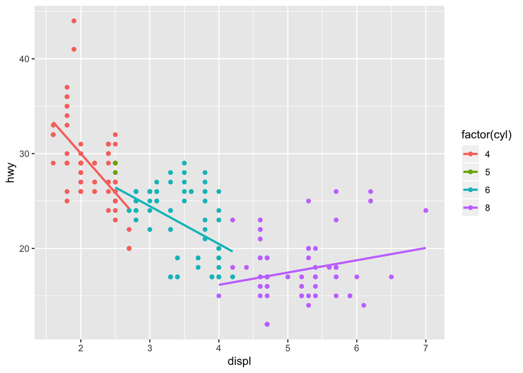

```r
ggplot(mpg, aes(x = displ, y = hwy, colour = factor(cyl))) +
    geom_point() + geom_smooth(method = "lm", se = FALSE)
```

- Add code to do the following:
  - `x` and `y` axes are
    - Plotted on a logarithmic scale
    - Show breaks at 2, 3, 4, 5, 6, and 7 (x-axis) and 20, 30, and 40 (y-axis)
  - Set the labels as follows:
    - Label for the x-axis is `Displacement`
    - Label for the y-axis is `MPG, highway`
    - Label for the legend is `Cylinders`
    - Title of the plot is `Fuel economy and engine size`
  - Observations are grouped into facets by `year`
    - Change the facet labels to `Model year 1999` and `Model year 2008`
- The resulting plot looks like this:

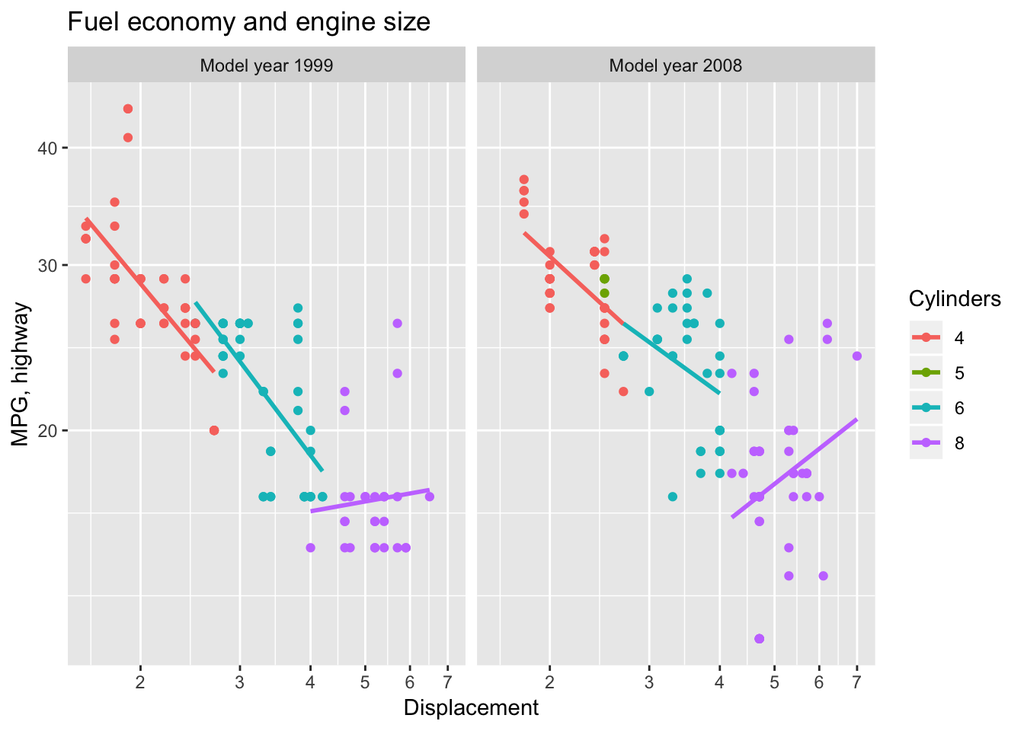

# Exercise set 3

For tasks 6–11, use the following data:

```r
library(tidyverse)
data(mpg, package = "ggplot2")
mpg %>% tbl_df
```

```
## # A tibble: 234 x 11
##    manufacturer model displ  year   cyl trans drv     cty   hwy fl    class
##    <chr>        <chr> <dbl> <int> <int> <chr> <chr> <int> <int> <chr> <chr>
##  1 audi         a4      1.8  1999     4 auto… f        18    29 p     comp…
##  2 audi         a4      1.8  1999     4 manu… f        21    29 p     comp…
##  3 audi         a4      2    2008     4 manu… f        20    31 p     comp…
##  4 audi         a4      2    2008     4 auto… f        21    30 p     comp…
##  5 audi         a4      2.8  1999     6 auto… f        16    26 p     comp…
##  6 audi         a4      2.8  1999     6 manu… f        18    26 p     comp…
##  7 audi         a4      3.1  2008     6 auto… f        18    27 p     comp…
##  8 audi         a4 q…   1.8  1999     4 manu… 4        18    26 p     comp…
##  9 audi         a4 q…   1.8  1999     4 auto… 4        16    25 p     comp…
## 10 audi         a4 q…   2    2008     4 manu… 4        20    28 p     comp…
## # … with 224 more rows
```

## Task 6

- Use the `select` verb to extract the following columns from `mpg`: `manufacturer`, `model`, `displ`, `year`, `cyl`, `trans`, `cty`, `hwy` and view the output, which should look something like this:

```
## # A tibble: 234 x 8
##    manufacturer model      displ  year   cyl trans        cty   hwy
##    <chr>        <chr>      <dbl> <int> <int> <chr>      <int> <int>
##  1 audi         a4           1.8  1999     4 auto(l5)      18    29
##  2 audi         a4           1.8  1999     4 manual(m5)    21    29
##  3 audi         a4           2    2008     4 manual(m6)    20    31
##  4 audi         a4           2    2008     4 auto(av)      21    30
##  5 audi         a4           2.8  1999     6 auto(l5)      16    26
##  6 audi         a4           2.8  1999     6 manual(m5)    18    26
##  7 audi         a4           3.1  2008     6 auto(av)      18    27
##  8 audi         a4 quattro   1.8  1999     4 manual(m5)    18    26
##  9 audi         a4 quattro   1.8  1999     4 auto(l5)      16    25
## 10 audi         a4 quattro   2    2008     4 manual(m6)    20    28
## # … with 224 more rows
```

- Create a new data frame called `mpg2` that contains this subset of columns (i.e.):

```r
mpg2 <- mpg %>% [ your code from the previous step ]
```

## Task 7

- Working with `mpg2`, use the `mutate` verb to create two new columns:
  - `displ2` is equal to the square of displacement (i.e., `displ * displ` or `displ^2`)
  - `vol_per_cyl` that is equal to `displ` divided by `cyl` (i.e., `displ / cyl`, rounded to the nearest 1/100th of a liter (i.e., two decimal places)
- Your output should look like this:

```
## # A tibble: 234 x 10
##    manufacturer model displ  year   cyl trans   cty   hwy displ2
##    <chr>        <chr> <dbl> <int> <int> <chr> <int> <int>  <dbl>
##  1 audi         a4      1.8  1999     4 auto…    18    29   3.24
##  2 audi         a4      1.8  1999     4 manu…    21    29   3.24
##  3 audi         a4      2    2008     4 manu…    20    31   4
##  4 audi         a4      2    2008     4 auto…    21    30   4
##  5 audi         a4      2.8  1999     6 auto…    16    26   7.84
##  6 audi         a4      2.8  1999     6 manu…    18    26   7.84
##  7 audi         a4      3.1  2008     6 auto…    18    27   9.61
##  8 audi         a4 q…   1.8  1999     4 manu…    18    26   3.24
##  9 audi         a4 q…   1.8  1999     4 auto…    16    25   3.24
## 10 audi         a4 q…   2    2008     4 manu…    20    28   4
## # … with 224 more rows, and 1 more variable: vol_per_cyl <dbl>
```

- Create a new data frame called `mpg3` that contains this new data frame with the two extra columns

```r
mpg3 <- mpg2 %>% [ your code from the previous step ]
```

## Task 8

- Working with `mpg3`, use the `arrange` verb to re-order the rows in descending order of `vol_per_cyl`

```
## # A tibble: 234 x 10
##    manufacturer model displ  year   cyl trans   cty   hwy displ2
##    <chr>        <chr> <dbl> <int> <int> <chr> <int> <int>  <dbl>
##  1 chevrolet    corv…   7    2008     8 manu…    15    24   49
##  2 chevrolet    k150…   6.5  1999     8 auto…    14    17   42.2
##  3 chevrolet    corv…   6.2  2008     8 manu…    16    26   38.4
##  4 chevrolet    corv…   6.2  2008     8 auto…    15    25   38.4
##  5 jeep         gran…   6.1  2008     8 auto…    11    14   37.2
##  6 chevrolet    c150…   6    2008     8 auto…    12    17   36
##  7 dodge        dura…   5.9  1999     8 auto…    11    15   34.8
##  8 dodge        ram …   5.9  1999     8 auto…    11    15   34.8
##  9 chevrolet    c150…   5.7  1999     8 auto…    13    17   32.5
## 10 chevrolet    corv…   5.7  1999     8 manu…    16    26   32.5
## # … with 224 more rows, and 1 more variable: vol_per_cyl <dbl>
```

- Working again with `mpg3`, use the `filter` verb to extract the subset of rows corresponding to the `manufacturer` `chevrolet`, then use `arrange` to place these rows in descending order by `vol_per_cyl`

```
## # A tibble: 19 x 10
##    manufacturer model displ  year   cyl trans   cty   hwy displ2
##    <chr>        <chr> <dbl> <int> <int> <chr> <int> <int>  <dbl>
##  1 chevrolet    corv…   7    2008     8 manu…    15    24  49
##  2 chevrolet    k150…   6.5  1999     8 auto…    14    17  42.2
##  3 chevrolet    corv…   6.2  2008     8 manu…    16    26  38.4
##  4 chevrolet    corv…   6.2  2008     8 auto…    15    25  38.4
##  5 chevrolet    c150…   6    2008     8 auto…    12    17  36
##  6 chevrolet    c150…   5.7  1999     8 auto…    13    17  32.5
##  7 chevrolet    corv…   5.7  1999     8 manu…    16    26  32.5
##  8 chevrolet    corv…   5.7  1999     8 auto…    15    23  32.5
##  9 chevrolet    k150…   5.7  1999     8 auto…    11    15  32.5
## 10 chevrolet    c150…   5.3  2008     8 auto…    14    20  28.1
## 11 chevrolet    c150…   5.3  2008     8 auto…    11    15  28.1
## 12 chevrolet    c150…   5.3  2008     8 auto…    14    20  28.1
## 13 chevrolet    k150…   5.3  2008     8 auto…    14    19  28.1
## 14 chevrolet    k150…   5.3  2008     8 auto…    11    14  28.1
## 15 chevrolet    mali…   2.4  1999     4 auto…    19    27   5.76
## 16 chevrolet    mali…   2.4  2008     4 auto…    22    30   5.76
## 17 chevrolet    mali…   3.6  2008     6 auto…    17    26  13.0
## 18 chevrolet    mali…   3.5  2008     6 auto…    18    29  12.2
## 19 chevrolet    mali…   3.1  1999     6 auto…    18    26   9.61
## # … with 1 more variable: vol_per_cyl <dbl>
```

- Working again with `mpg3`, use the `group_by` verb to group this data frame by `manufacturer` and `year`. Then, for each unique pair of `manufacturer` and `year`, calculate the largest value of `vol_per_cyl`. Call this new column `max_vol_per_cyl`.

```
## # A tibble: 30 x 3
## # Groups:   manufacturer [?]
##    manufacturer  year max_vol_per_cyl
##    <chr>        <int>           <dbl>
##  1 audi          1999            0.47
##  2 audi          2008            0.52
##  3 chevrolet     1999            0.81
##  4 chevrolet     2008            0.88
##  5 dodge         1999            0.74
##  6 dodge         2008            0.71
##  7 ford          1999            0.7
##  8 ford          2008            0.68
##  9 honda         1999            0.4
## 10 honda         2008            0.5
## # … with 20 more rows
```

- Create a new data frame called `mpg4` that contains this new data frame

```r
mpg4 <- mpg3 %>% [ your code from the previous step ]
```

## Task 9

- Working with `mpg4`, use the `spread` verb from the `tidyr` package to create a data frame that looks like this:

```
## # A tibble: 15 x 3
## # Groups:   manufacturer [15]
##    manufacturer `1999` `2008`
##    <chr>         <dbl>  <dbl>
##  1 audi          0.47    0.52
##  2 chevrolet     0.81    0.88
##  3 dodge         0.74    0.71
##  4 ford          0.7     0.68
##  5 honda         0.4     0.5
##  6 hyundai       0.6     0.6
##  7 jeep          0.67    0.76
##  8 land rover    0.570   0.55
##  9 lincoln       0.68    0.68
## 10 mercury       0.67    0.67
## 11 nissan        0.6     0.7
## 12 pontiac       0.63    0.66
## 13 subaru        0.62    0.62
## 14 toyota        0.68    0.71
## 15 volkswagen    0.5     0.6
```

- *Hint:* the key/value pair in `mpg4` is made up of `year` (key) and `max_vol_per_cyl` (value).
- Create a new data frame called `mpg5` that contains this new data frame

```r
mpg5 <- mpg4 %>% [ your code from the previous step ]
```

## Task 10

- Working with `mpg5`, create a new column representing the difference between the value of the columns `2008` and `1999`. Call this variable `change`
- *Note:* Refer to the column names using the backtick character (`` ` ``) so that R knows you mean `2008` the column name, and not `2008` the number. That is, you should write code referring to the column as `` `2008` `` and not `2008`.

```
## # A tibble: 15 x 4
## # Groups:   manufacturer [15]
##    manufacturer `1999` `2008`  change
##    <chr>         <dbl>  <dbl>   <dbl>
##  1 audi          0.47    0.52  0.05
##  2 chevrolet     0.81    0.88  0.0700
##  3 dodge         0.74    0.71 -0.03
##  4 ford          0.7     0.68 -0.0200
##  5 honda         0.4     0.5   0.100
##  6 hyundai       0.6     0.6   0
##  7 jeep          0.67    0.76  0.0900
##  8 land rover    0.570   0.55 -0.0200
##  9 lincoln       0.68    0.68  0
## 10 mercury       0.67    0.67  0
## 11 nissan        0.6     0.7   0.100
## 12 pontiac       0.63    0.66  0.03
## 13 subaru        0.62    0.62  0
## 14 toyota        0.68    0.71  0.0300
## 15 volkswagen    0.5     0.6   0.100
```

- Create a new data frame called `mpg6` that contains this new data frame

```r
mpg6 <- mpg5 %>% [ your code from the previous step ]
```

## Task 11

- Working with `mpg6`, rename the columns `1999` and `2008` to be `max_vpc_1999` and `max_vpc_2008`.
- Then use the `gather` verb to create a key/value pair based on the three numeric columns, with the key column called `variable` and the value column called `value`.
- The result should look like this (put `%>% View` at the end of your code to see all of the data in tabular form via the RStudio GUI).

```
##    manufacturer     variable value
## 1          audi max_vpc_1999  0.47
## 2     chevrolet max_vpc_1999  0.81
## 3         dodge max_vpc_1999  0.74
## 4          ford max_vpc_1999  0.70
## 5         honda max_vpc_1999  0.40
## 6       hyundai max_vpc_1999  0.60
## 7          jeep max_vpc_1999  0.67
## 8    land rover max_vpc_1999  0.57
## 9       lincoln max_vpc_1999  0.68
## 10      mercury max_vpc_1999  0.67
## 11       nissan max_vpc_1999  0.60
## 12      pontiac max_vpc_1999  0.63
## 13       subaru max_vpc_1999  0.62
## 14       toyota max_vpc_1999  0.68
```

[output cut: 31 more lines]

# Exercise set 4

- Data for tasks 12–14 is obtained by installing the `nycflights13` package:

```r
install.packages("nycflights13")
```

- Load these packages

```r
library(tidyverse)
library(nycflights13)
flights %>% tbl_df
```

```
## # A tibble: 336,776 x 19
##     year month   day dep_time sched_dep_time dep_delay arr_time
##    <int> <int> <int>    <int>          <int>     <dbl>    <int>
##  1  2013     1     1      517            515         2      830
##  2  2013     1     1      533            529         4      850
##  3  2013     1     1      542            540         2      923
##  4  2013     1     1      544            545        -1     1004
##  5  2013     1     1      554            600        -6      812
##  6  2013     1     1      554            558        -4      740
##  7  2013     1     1      555            600        -5      913
##  8  2013     1     1      557            600        -3      709
##  9  2013     1     1      557            600        -3      838
## 10  2013     1     1      558            600        -2      753
## # … with 336,766 more rows, and 12 more variables: sched_arr_time <int>,
## #   arr_delay <dbl>, carrier <chr>, flight <int>, tailnum <chr>,
## #   origin <chr>, dest <chr>, air_time <dbl>, distance <dbl>, hour <dbl>,
## #   minute <dbl>, time_hour <dttm>
```

```r
airlines %>% tbl_df
```

```
## # A tibble: 16 x 2
##    carrier name
##    <chr>   <chr>
##  1 9E      Endeavor Air Inc.
##  2 AA      American Airlines Inc.
##  3 AS      Alaska Airlines Inc.
##  4 B6      JetBlue Airways
##  5 DL      Delta Air Lines Inc.
##  6 EV      ExpressJet Airlines Inc.
##  7 F9      Frontier Airlines Inc.
##  8 FL      AirTran Airways Corporation
##  9 HA      Hawaiian Airlines Inc.
## 10 MQ      Envoy Air
## 11 OO      SkyWest Airlines Inc.
## 12 UA      United Air Lines Inc.
## 13 US      US Airways Inc.
## 14 VX      Virgin America
## 15 WN      Southwest Airlines Co.
## 16 YV      Mesa Airlines Inc.
```

```r
weather %>% tbl_df
```

```
## # A tibble: 26,115 x 15
##    origin  year month   day  hour  temp  dewp humid wind_dir wind_speed
##    <chr>  <dbl> <dbl> <int> <int> <dbl> <dbl> <dbl>    <dbl>      <dbl>
##  1 EWR     2013     1     1     1  39.0  26.1  59.4      270      10.4
##  2 EWR     2013     1     1     2  39.0  27.0  61.6      250       8.06
##  3 EWR     2013     1     1     3  39.0  28.0  64.4      240      11.5
##  4 EWR     2013     1     1     4  39.9  28.0  62.2      250      12.7
##  5 EWR     2013     1     1     5  39.0  28.0  64.4      260      12.7
##  6 EWR     2013     1     1     6  37.9  28.0  67.2      240      11.5
##  7 EWR     2013     1     1     7  39.0  28.0  64.4      240      15.0
##  8 EWR     2013     1     1     8  39.9  28.0  62.2      250      10.4
##  9 EWR     2013     1     1     9  39.9  28.0  62.2      260      15.0
## 10 EWR     2013     1     1    10  41    28.0  59.6      260      13.8
## # … with 26,105 more rows, and 5 more variables: wind_gust <dbl>,
## #   precip <dbl>, pressure <dbl>, visib <dbl>, time_hour <dttm>
```

## Task 12

- Create two new data frames with subsets of columns from the `flights` and `weather` data frames, named `flights2` and `weather2`.

```r
flights2 <- flights %>% select(origin, year, month, day, hour,
    sched_dep_time, dep_delay, carrier)
weather2 <- weather %>% select(origin, year, month, day, hour,
    precip, wind_speed, visib)
```

```
## # A tibble: 336,776 x 9
##    origin  year month   day  hour sched_dep_time dep_delay carrier name
##    <chr>  <int> <int> <int> <dbl>          <int>     <dbl> <chr>   <chr>
##  1 EWR     2013     1     1     5            515         2 UA      United …
##  2 LGA     2013     1     1     5            529         4 UA      United …
##  3 JFK     2013     1     1     5            540         2 AA      America…
##  4 JFK     2013     1     1     5            545        -1 B6      JetBlue…
##  5 LGA     2013     1     1     6            600        -6 DL      Delta A…
##  6 EWR     2013     1     1     5            558        -4 UA      United …
##  7 EWR     2013     1     1     6            600        -5 B6      JetBlue…
##  8 LGA     2013     1     1     6            600        -3 EV      Express…
##  9 JFK     2013     1     1     6            600        -3 B6      JetBlue…
## 10 LGA     2013     1     1     6            600        -2 AA      America…
## # … with 336,766 more rows
```

- Which column was used as the key for this join?
- Next, write code to perform an outer join between `flights2` and `weather2` that includes all rows from `flights2`. Your output should look like this:

```
## # A tibble: 336,776 x 11
##    origin  year month   day  hour sched_dep_time dep_delay carrier precip
##    <chr>  <dbl> <dbl> <int> <dbl>          <int>     <dbl> <chr>    <dbl>
##  1 EWR     2013     1     1     5            515         2 UA           0
##  2 LGA     2013     1     1     5            529         4 UA           0
##  3 JFK     2013     1     1     5            540         2 AA           0
##  4 JFK     2013     1     1     5            545        -1 B6           0
##  5 LGA     2013     1     1     6            600        -6 DL           0
##  6 EWR     2013     1     1     5            558        -4 UA           0
##  7 EWR     2013     1     1     6            600        -5 B6           0
##  8 LGA     2013     1     1     6            600        -3 EV           0
##  9 JFK     2013     1     1     6            600        -3 B6           0
## 10 LGA     2013     1     1     6            600        -2 AA           0
## # … with 336,766 more rows, and 2 more variables: wind_speed <dbl>,
## #   visib <dbl>
```

- Why are there `NA` values under `precip`, `wind_speed`, and `visib`?

## Task 13

- Which airlines have the worst departure delays when conditions are ideal? First, we need to know what it means for conditions to be ideal. Precipition and high winds are bad, so we need to know their minimum values. Visibility is good, so we need to know its maximum value. In the code that follows, `na.rm=TRUE` allows us to ignore any weather data where one of these variables might be missing (i.e., `NA`). You can execute this code or just look at mine:

```r
weather2 %>% summarise(min_precip = min(precip, na.rm = TRUE),
    min_wind = min(wind_speed, na.rm = TRUE), max_visib = max(visib,
        na.rm = TRUE))
```

```
## # A tibble: 1 x 3
##   min_precip min_wind max_visib
##        <dbl>    <dbl>     <dbl>
## 1          0        0        10
```

- Now write code to create a new data frame based on `flights2` joined with `weather2`
  - The new data frame should only include rows corresponding with flights that had ideal conditions upon departure.
  - Name this new data frame `good_weather_delays`
  - Your code should include a call to `inner_join` and another call to `filter`. Use the `%>%` operator to chain all of this together
- The data frame `good_weather_delays` should look like this:

```
## # A tibble: 8,278 x 11
##    origin  year month   day  hour sched_dep_time dep_delay carrier precip
##    <chr>  <dbl> <dbl> <int> <dbl>          <int>     <dbl> <chr>    <dbl>
##  1 LGA     2013     1     5    18           1800        -5 DL           0
##  2 LGA     2013     1     5    18           1810       -11 MQ           0
##  3 LGA     2013     1     5    18           1800         0 EV           0
##  4 LGA     2013     1     5    18           1805        -3 DL           0
##  5 LGA     2013     1     5    18           1800        11 WN           0
##  6 LGA     2013     1     5    18           1820        -3 DL           0
##  7 LGA     2013     1     5    18           1830       -10 MQ           0
##  8 LGA     2013     1     5    18           1810        15 AA           0
##  9 LGA     2013     1     5    18           1855        -6 US           0
## 10 LGA     2013     1     7    16           1600        -9 US           0
## # … with 8,268 more rows, and 2 more variables: wind_speed <dbl>,
## #   visib <dbl>
```

- To answer the question, “Which airlines have the worst departure delays when conditions are ideal?” write code to:
  - Use this data frame (`good_weather_delays`)
  - Group observations by carrier
  - Calculate the average departure delay (`dep_delay`)
  - Order rows by this new summary statistic
  - Join the `airlines` data frame to get the full name of the airlines
- Your output should look like this:

```
## # A tibble: 15 x 3
##    carrier dep_delay name
##    <chr>       <dbl> <chr>
##  1 YV          14.6  Mesa Airlines Inc.
##  2 EV          10.8  ExpressJet Airlines Inc.
##  3 B6           8.58 JetBlue Airways
##  4 9E           8.28 Endeavor Air Inc.
##  5 FL           8.14 AirTran Airways Corporation
##  6 WN           8.01 Southwest Airlines Co.
##  7 VX           7.42 Virgin America
##  8 UA           6.19 United Air Lines Inc.
##  9 F9           4.92 Frontier Airlines Inc.
## 10 MQ           3.96 Envoy Air
## 11 DL           2.72 Delta Air Lines Inc.
## 12 AA           1.32 American Airlines Inc.
## 13 AS          -0.4  Alaska Airlines Inc.
## 14 US          -1.28 US Airways Inc.
## 15 HA          -3.6  Hawaiian Airlines Inc.
```

- Create a new data frame using the output from Task 13. Call this data frame `avg_good_weather_delays`

```r
avg_good_weather_delays <- [ your code from the previous step ]
```

# Task 14

- Create a plot that summarizes the distribution of delays when weather conditions were ideal
- This is mine:

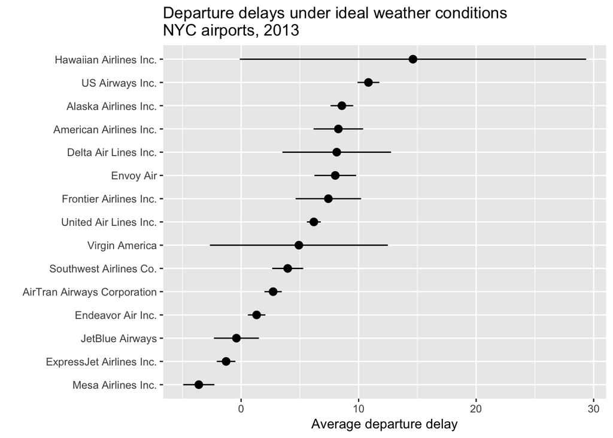

```r
ranked_airline_labels <- avg_good_weather_delays %>% transmute(carrier,
    name = factor(-row_number(), labels = name))
```

- I joined this new data frame (`ranked_airline_labels`) with the `good_weather_delays` data frame, then passed the result into ggplot2
- I mapped `name` to the `x` (not `y`) axis, and mapped `dep_delay` to the `y` axis. This is reverse from what you see, but I did it because `stat_summary`, which creates the points with error bars, expects to summarize over `y`
- To reverse the orientation of the plot, I added `coord_flip()` to my ggplot call, which transposes the plot by 90 degrees
- I then relabeled the axes and added a title

## Solutions

```r
library(tidyverse)
library(nycflights13)
## Task 1
ggplot(mpg, aes(x = displ, y = hwy, colour = trans)) + geom_point()
## Task 2
ggplot(mpg, aes(x = displ, y = hwy)) + geom_point(colour = "red") + geom_smooth()
## Task 3
ggplot(mpg, aes(x = displ, y = hwy, colour = drv)) + geom_point() + geom_smooth(method = "lm",
    se = FALSE)
## Task 4
ggplot(mpg, aes(x = displ, y = hwy, colour = factor(cyl))) + geom_point() +
    geom_smooth()
## Task 5
ggplot(mpg, aes(x = displ, y = hwy, colour = factor(cyl))) + geom_point() +
    geom_smooth(method = "lm", se = FALSE) + scale_x_log10(breaks = 2:7) + scale_y_log10(breaks = c(20,
    30, 40)) + facet_wrap(~year, labeller = as_labeller(c(`1999` = "Model year 1999",
    `2008` = "Model year 2008"))) + labs(x = "Displacement", y = "MPG, highway",
    colour = "Cylinders", title = "Fuel economy and engine size")
## Task 6
mpg2 <- mpg %>% select(manufacturer, model, displ, year, cyl, trans, cty, hwy)
## Task 7
mpg3 <- mpg2 %>% mutate(displ2 = displ^2, vol_per_cyl = round(displ/cyl, 2))
## Task 8
mpg3 %>% arrange(desc(vol_per_cyl))
mpg3 %>% filter(manufacturer == "chevrolet") %>% arrange(desc(vol_per_cyl))
mpg4 <- mpg3 %>% group_by(manufacturer, year) %>% summarise(max_vol_per_cyl = max(vol_per_cyl))
## Task 9
mpg5 <- mpg4 %>% spread(year, max_vol_per_cyl)
## Task 10
mpg6 <- mpg5 %>% mutate(change = `2008` - `1999`)
## Task 11
mpg6 %>% rename(max_vpc_1999 = `1999`, max_vpc_2008 = `2008`) %>% gather(variable,
    value, -manufacturer) %>% as.data.frame
## Task 12
flights2 <- flights %>% select(origin, year, month, day, hour, sched_dep_time,
    dep_delay, carrier)
weather2 <- weather %>% select(origin, year, month, day, hour, precip, wind_speed,
    visib)
flights2 %>% inner_join(airlines)
flights2 %>% left_join(weather2)
## Task 13
weather2 %>% summarise(min_precip = min(precip, na.rm = TRUE), min_wind = min(wind_speed,
    na.rm = TRUE), max_visib = max(visib, na.rm = TRUE))
good_weather_delays <- flights2 %>% inner_join(weather2) %>% filter(precip ==
    0 & wind_speed == 0 & visib == 10)
avg_good_weather_delays <- good_weather_delays %>% group_by(carrier) %>% summarise(dep_delay = mean(dep_delay,
    na.rm = TRUE)) %>% arrange(desc(dep_delay)) %>% inner_join(airlines)
## Task 14
ranked_airline_labels <- avg_good_weather_delays %>% transmute(carrier, name = factor(-row_number(),
    labels = name))
good_weather_delays %>% inner_join(ranked_airline_labels) %>% ggplot(aes(x = name,
    y = dep_delay)) + stat_summary() + coord_flip() + labs(x = "", y = "Average departure delay",
    title = "Departure delays under ideal weather conditions\nNYC airports, 2013")
```